# R Markdown

05/07/2018

## Introduction

R Markdown provides an authoring framework for data science. A single R Markdown file can be use to both

- save and execute code
- generate high quality reports that can be shared with an audience

R Markdown documents are fully reproducible and support dozens of static and dynamic output formats, such as

- web page
- PDF
- MS Word
- slide show
- dashboard
- notebook
- handout
- book
- package vignette or
- other format.

## How It Works

This is an R Markdown file, a plain text file that has an extension `.Rmd`.

[figure not shown]

The file has three types of content

- An (optional) YAML header surrounded by `---`
- R code chunks surrounded `` ``` ``
- text mixed with simple text formatting

### A Notebook Interface

- When the file is open the file in RStudio IDE, it becomes a notebook interface for R.
- Each code chunk can be run by clicking the icon
- RStudio executes the code and display the results inline

### Rendering outut

- To generate a report from the file, run the render command

```r
library(rmarkdown)
render("Rmarkdown_Coles.Rmd")
```

- Or, click on button to render and preview

## How It Works

- R Markdown generates a new file that contains selected text, code and results from the .Rmd file.

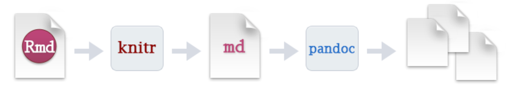

- When we run `render`, R Markdown feeds the .Rmd file to `knitr`, which executes all the code chunks and creates a new markdown (`.md`) document which includes the codes and it's output.
- The markdown file generated by `knitr` is then processed by `pandoc` which is responsible for creating the finished format
- Sounds complicated? R Markdown makes it extremely simple by doing all of process into a single `render` function or the `knit` button

## Code Chunks

The R Markdown file contains three code chunks

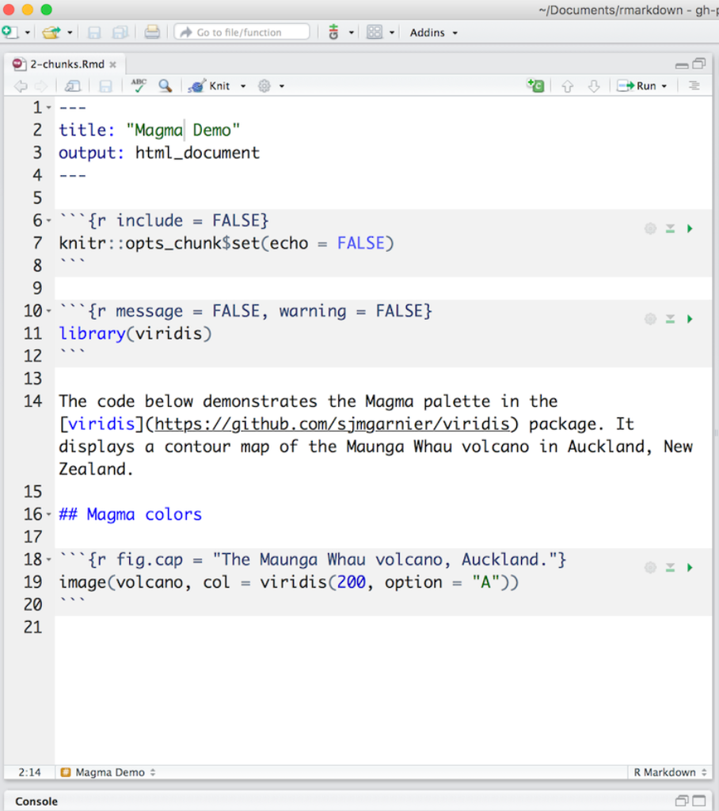

We can quickly insert chunks like these into file with

- the keayboard shortcut *Ctrl+Alt+I*  
  (OS X: *Cmd+Option+I*)
- the Add Chunk button in the editor toolbar
- or by typing the chunk delimiters `` ```{r} `` and ```

When .Rmd file is rendered, R Markdown will run each code chunk and embed the results beneath code chunk in final report

## Chunk Options

Chunk output can be customized with **knitr options**, arguments set the `{}` of a chunk header. In the previous example we use four arguments:

- `include = FALSE` prevents code and results from appearing in the finished file. R Markdown still run the code in the chunk, and the results can be used by other chunks.
- `message = FALSE` prevents messages that are generated by code from appearing in the finished file
- `warning = FALSE` prevents warnings that are generated by code from appearing in the finished file
- `fig.cap = "..."` adds a caption to graphical results

## Knitr Options for Code Chunk

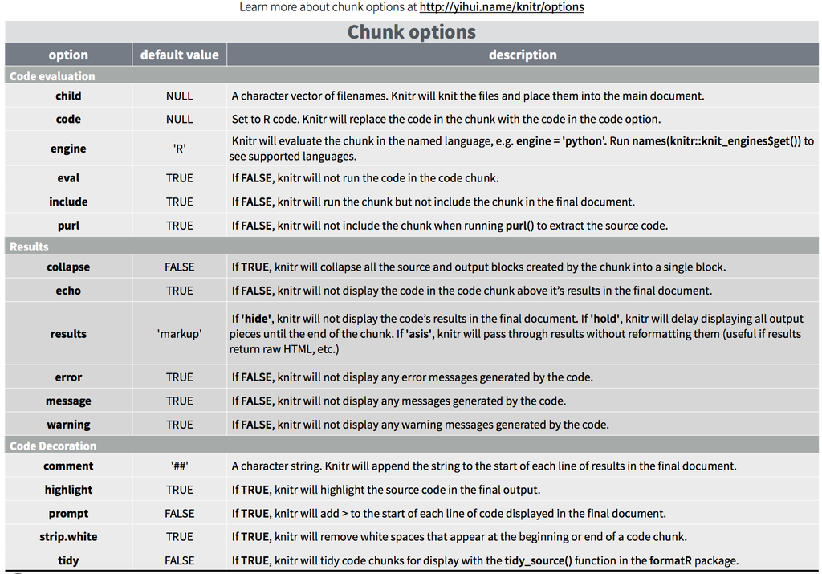

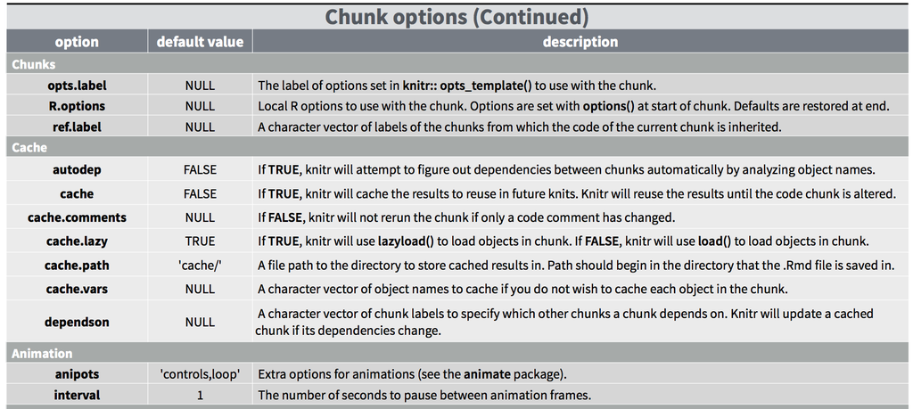

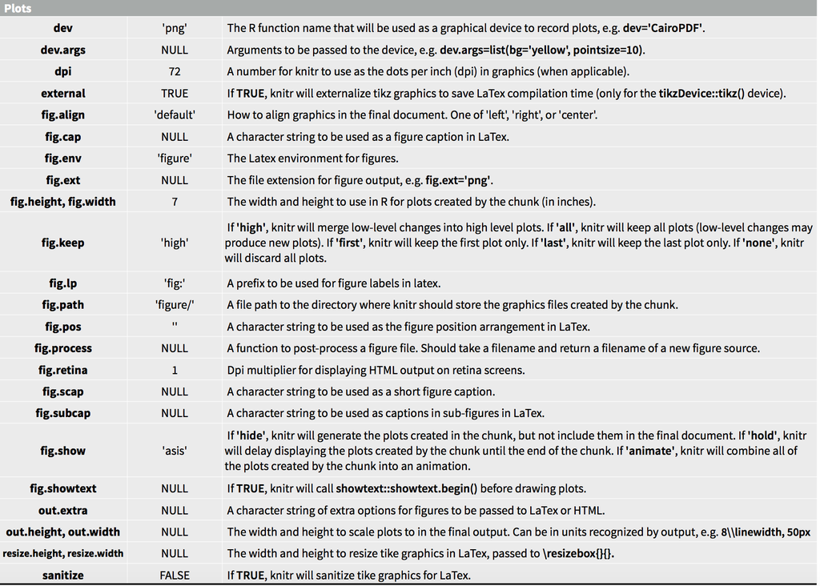

## Global Options

- To set global options that apply to every chunk in the file, call `knitr::opts_chunk$set` in a code chunk.

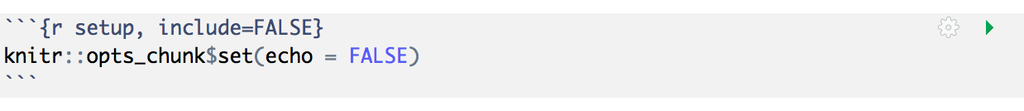

- Knitr will treat each option that you pass to `knitr::opts_chunk$set` as a global default that can be overwritten in individual chunk headers.

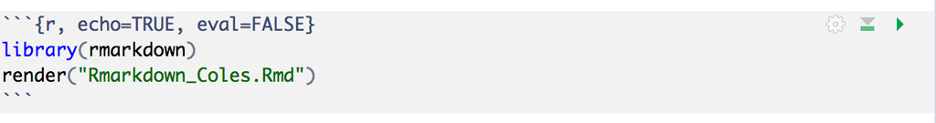

## Caching

- If document rendering becomes time consuming due to long computations you can use knitr caching to improve performance.
- [Knitr chunk and package options](https://yihui.name/knitr/options/) describes how caching works and the [Cache examples](https://yihui.name/knitr/demo/cache/) provide additional details.

### Reference:

- [R Markdown Reference Guide](https://www.rstudio.com/wp-content/uploads/2015/03/rmarkdown-reference.pdf)
- [knitr options](https://yihui.name/knitr/options/)

## Some hack for Code Chunk

- Add a blank chunk

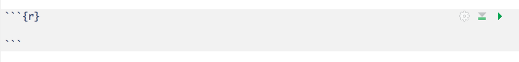

## Some hack for Code Chunk

- Use the little circle on top right to expand the menu and select choices

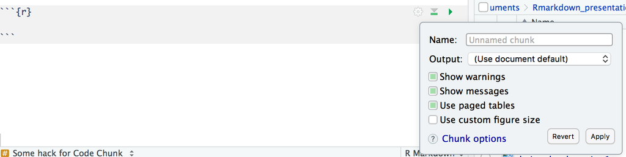

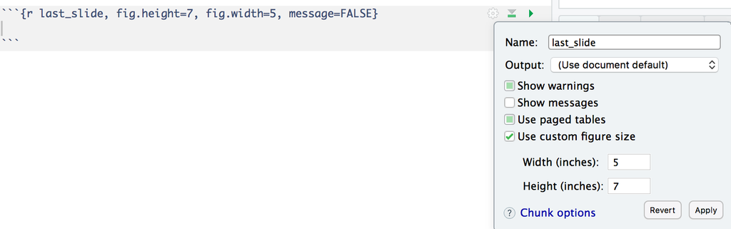

## Some hack for Code Chunk

- Type a chunk option in ````{r, cache = }` to see the all options in cache group
- Use `cache` unless strong reason against it
- For resizing figure, try `fig.width` , `fig.height`, `out.width`, `out.height`, `fig.aspect`
- Always give a name to each chunk (we will learn its benefit later)